# Introduction à la modélisation statistique bayésienne

Ladislas Nalborczyk & Thierry Phénix

### Planning

Cours 1: Introduction à l'inférence bayésienne

Cours 2: Modèle beta-binomial

Cours 3 & 4: Modèle de régression linéaire

Cours 5: Markov Chain Monte Carlo

Cours 6: Modèle linéaire généralisé

Cours 7: Comparaison de modèles

**Cours 8: Modèles multi-niveaux**

Cours 9: Introduction à `brms`

Cours 10: Data Hackaton

### Modèles multi-niveaux

But: construire un modèle qui puisse **apprendre à plusieurs niveaux**, qui puisse produire des estimations qui seront informées par les différents groupes présents dans les données. Nous allons suivre l'exemple suivant tout au long de ce cours.

Imaginons que nous ayons construit un robot visiteur de cafés, et que celui-ci s'amuse à mesurer le temps d'attente après avoir commandé. Ce robot visite 20 cafés différents, 5 fois le matin et 5 fois l'après-midi.

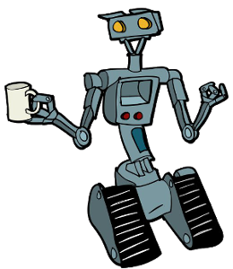

### Robot et café

```r
d <- read.csv("robot.csv")
head(d, 15)
```

```
   cafe afternoon      wait
1     1         0 4.9989926
2     1         1 2.2133944
3     1         0 4.1866730
4     1         1 3.5624399
5     1         0 3.9956779
6     1         1 2.8957176
7     1         0 3.7804582
8     1         1 2.3844837
9     1         0 3.8617982
10    1         1 2.5800004
11    2         0 2.7421223
12    2         1 1.3525907
13    2         0 2.5215095
14    2         1 0.9628102
15    2         0 1.9543977
```

### Robot et café, premier modèle

On peut construire un premier modèle, qui estime le temps moyen (sur tous les bistrots confondus) pour être servi.

\[ \begin{align} w_{i} &\sim \mathrm{Normal}(\mu_{i}, \sigma) \\ \mu_{i} &= \alpha \\ \alpha &\sim \mathrm{Normal}(5, 10) \\ \sigma &\sim \mathrm{HalfCauchy}(0, 2) \\ \end{align} \]

```r
library(rethinking)

mod1 <- map2stan(alist(
    wait ~ dnorm(mu, sigma),
    mu <- a,
    a ~ dnorm(5, 10),
    sigma ~ dcauchy(0, 2) ),
    data = d,
    warmup = 2000, iter = 5000,
    chains = 2, cores = parallel::detectCores()
    )
```

### Half-Cauchy

\[ p(x|x_{0}, \gamma) = \Big(\pi \gamma \Big[1 + \big(\tfrac{x-x_{0}}{\gamma}\big)^{2}\Big] \Big)^{-1} \]

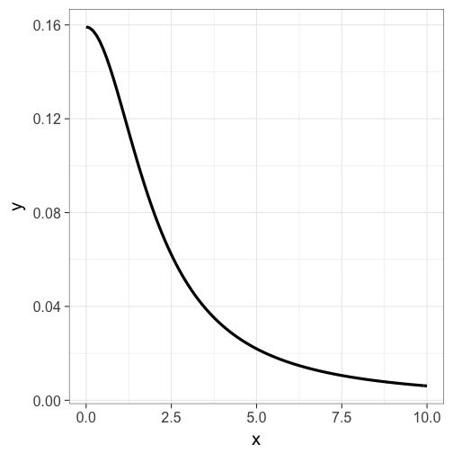

```r
ggplot(data = data.frame(x = c(0, 10) ), aes(x = x) ) +
    stat_function(
        fun = dcauchy,
        args = list(location = 0, scale = 2), size = 1.5
        ) +
    theme_bw(base_size = 20)
```

### Diagnostic plot

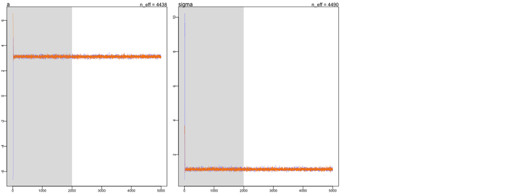

```r
plot(mod1)
```

```r
precis(mod1, prob = 0.95)
```

```
      Mean StdDev lower 0.95 upper 0.95 n_eff Rhat
a     3.12   0.08       2.96       3.27  4438    1
sigma 1.14   0.06       1.03       1.26  4490    1
```

### Un intercept par café

Deuxième modèle qui estime un intercept par café. Équivalent à construire 20 *dummy variables*.

\[ \begin{align} w_{i} &\sim \mathrm{Normal}(\mu_{i},\sigma) \\ \mu_{i} &= \alpha_{\text{café}[i]} \\ \alpha_{\text{café}[i]} &\sim \mathrm{Normal}(5,10) \\ \sigma &\sim \mathrm{HalfCauchy}(0,2) \\ \end{align} \]

```r
mod2 <- map2stan(alist(
    wait ~ dnorm(mu, sigma),
    mu <- a_cafe[cafe],
    a_cafe[cafe] ~ dnorm(5, 10),
    sigma ~ dcauchy(0, 2) ),
    data = d,
    warmup = 2000, iter = 5000,
    chains = 2, cores = parallel::detectCores()
    )
```

### Un intercept par café

```r
precis(mod2, prob = 0.95, depth = 2)
```

```
           Mean StdDev lower 0.95 upper 0.95 n_eff Rhat
a_cafe[1]  3.45   0.26       2.94       3.98  6000    1
a_cafe[2]  1.73   0.26       1.21       2.23  6000    1
a_cafe[3]  3.32   0.25       2.85       3.83  6000    1
a_cafe[4]  2.80   0.27       2.28       3.32  6000    1
a_cafe[5]  1.46   0.25       0.94       1.94  6000    1
a_cafe[6]  3.64   0.26       3.12       4.15  6000    1
a_cafe[7]  2.94   0.26       2.43       3.45  6000    1
a_cafe[8]  3.17   0.26       2.65       3.67  6000    1
a_cafe[9]  3.34   0.26       2.84       3.85  6000    1
a_cafe[10] 3.10   0.26       2.57       3.60  6000    1
a_cafe[11] 1.92   0.26       1.42       2.41  6000    1
a_cafe[12] 3.49   0.26       2.98       4.01  6000    1
a_cafe[13] 3.22   0.26       2.69       3.71  6000    1
a_cafe[14] 2.63   0.26       2.12       3.11  6000    1
a_cafe[15] 3.48   0.26       2.97       4.01  6000    1
a_cafe[16] 3.00   0.26       2.50       3.51  6000    1
a_cafe[17] 3.88   0.26       3.37       4.39  6000    1
a_cafe[18] 5.53   0.27       5.01       6.04  6000    1
a_cafe[19] 2.97   0.26       2.46       3.45  6000    1
a_cafe[20] 3.36   0.27       2.83       3.86  6000    1
sigma      0.82   0.04       0.74       0.91  6000    1
```

### Modèle multi-niveaux

Est-ce qu'on ne pourrait pas faire en sorte que le temps mesuré au café 1 *informe* la mesure réalisée au café 2, et au café 3 ? Ainsi que le temps moyen pour être servi ? Nous allons apprendre le prior à partir des données…

\[ \begin{align} \text{Niveau 1}: w_{i} &\sim \mathrm{Normal}(\mu_{i},\sigma) \\ \mu_{i} &= \alpha_{\text{café}[i]} \\ \text{Niveau 2}: \alpha_{\text{café}} &\sim \mathrm{Normal}(\alpha,\sigma_{\text{café}}) \\ \alpha &\sim \mathrm{Normal}(5,10) \\ \sigma_{\text{café}} &\sim \mathrm{HalfCauchy}(0,2) \\ \sigma &\sim \mathrm{HalfCauchy}(0,2) \\ \end{align} \]

Le prior de l'intercept pour chaque café (\( \alpha_{\text{café}} \)) est maintenant fonction de deux paramètres (\( \alpha \) et \( \sigma_{\text{café}} \)). \( \alpha \) et \( \sigma_{\text{café}} \) sont appelés des **hyper-paramètres**, ce sont des paramètres pour des paramètres, et leurs priors sont appelés des **hyperpriors**. Il y a deux niveaux dans le modèle…

### Équivalences (encore)

\[ \begin{align} w_{i} &\sim \mathrm{Normal}(\mu_{i},\sigma) \\ \mu_{i} &= \alpha_{\text{café}[i]} \\ \alpha_{\text{café}} &\sim \mathrm{Normal}(\alpha,\sigma_{\text{café}}) \\ \end{align} \]

NB: \( \alpha \) est ici défini dans le prior de \( \alpha_{\text{café}} \) mais on pourrait, de la même manière, le définir dans le modèle linéaire:

\[ \begin{align} w_{i} &\sim \mathrm{Normal}(\mu_{i},\sigma) \\ \mu_{i} &= \alpha + \alpha_{\text{café}[i]} \\ \alpha_{\text{café}} &\sim \mathrm{Normal}(0, \sigma_{\text{café}}) \\ \alpha &\sim \mathrm{Normal}(5, 10) \\ \end{align} \]

On peut toujours “enlever” la moyenne d'une distribution gaussienne et la considérer comme une constante plus une gaussienne centrée sur zéro.

NB: quand \( \alpha \) est défini dans le modèle linéaire, les \( \alpha_{\text{café}} \) représentent des déviations de l'intercept moyen. Il faut donc ajouter \( \alpha \) et \( \alpha_{\text{café}} \) pour obtenir le temps d'attente moyen par café…

### Équivalences (encore)

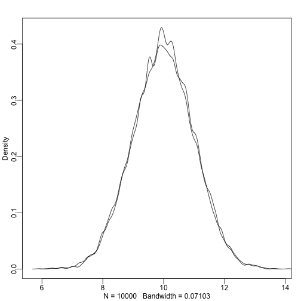

```r
y1 <- rnorm(1e4, 10, 1)
y2 <- 10 + rnorm(1e4, 0, 1)

dens(y1)
dens(y2, add = TRUE)
```

### Modèle multi-niveaux

```r
mod3 <- map2stan(alist(
    wait ~ dnorm(mu, sigma),
    mu <- a_cafe[cafe],
    a_cafe[cafe] ~ dnorm(a, sigma_cafe),
    a ~ dnorm(5, 10),
    sigma ~ dcauchy(0, 2),
    sigma_cafe ~ dcauchy(0, 2) ),
    data = d,
    warmup = 2000, iter = 5000,
    chains = 2, cores = parallel::detectCores() )
```

Ce modèle a 23 paramètres, l'intercept général \( \alpha \), la variance générale \( \sigma \), la variance entre les cafés \( \sigma_{\text{café}} \), et un intercept par café.

### Shrinkage

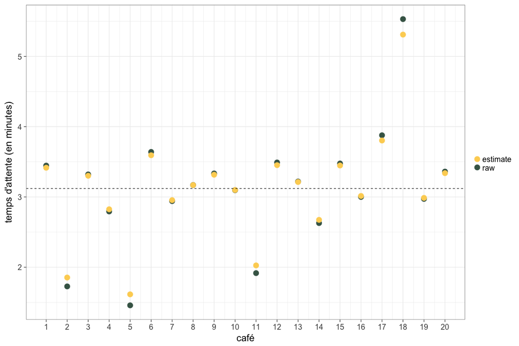

### Pooling

Le *shrinkage* observé slide précédente est dû à des phénomènes de partage (*pooling*) de l'information entre les cafés. L'estimation de l'intercept pour chaque café informe l'estimation de l'intercept des autres cafés, ainsi que l'estimation de l'intercept général (i.e., la moyenne générale).

On distingue en général trois perspectives (ou stratégies):

- **complete pooling**: on suppose que le temps d'attente est invariant, on estime un intercept commun (`mod1`)
- **no pooling**: on suppose que les temps d'attente de chaque café sont uniques et indépendants: on estime un intercept par café, mais sans informer le *niveau* supérieur (`mod2`)
- **partial pooling**: on utilise un prior adaptatif, comme dans l'exemple précédent (`mod3`)

La stratégie *complete pooling* en général *underfit* les données (faibles capacités de prédiction) tandis que le stratégie *no pooling* revient à *overfitter* les données (faibles capacités de prédiction ici aussi). La stratégie *partial pooling* (celle des modèles multi-niveaux) permet de balancer *underfitting* et *overfitting*.

### Comparaison de modèles

On peut comparer ces trois modèles en utilisant le WAIC (discuté au cours n°7).

```r
compare(mod1, mod2, mod3)
```

```
      WAIC pWAIC dWAIC weight    SE   dSE
mod3 507.6  18.1   0.0   0.67 16.54    NA
mod2 509.0  19.5   1.4   0.33 16.72  2.57
mod1 622.4   2.1 114.8   0.00 21.06 21.25
```

On remarque que le modèle 3 a seulement 18 *effective parameters* (*pWAIC*), et moins de paramètres que le modèle 2, alors qu'il en a *en réalité* 2 de plus…

`coef(mod3)["sigma_cafe"]` nous donne le sigma du prior adaptatif des \( \alpha_{\text{café}} \) (\( \sigma_{\text{café}} = 0.86 \)). On remarque que ce sigma est très faible et correspond à assigner un prior très contraignant, ou *régularisateur*.

### Comparaison de modèles

On compare le premier modèle (*complete pooling model*) et le troisième modèle (*partial pooling model*).

```r
precis(mod1, prob = 0.95)
```

```
      Mean StdDev lower 0.95 upper 0.95 n_eff Rhat
a     3.12   0.08       2.96       3.27  4438    1
sigma 1.14   0.06       1.03       1.26  4490    1
```

```r
precis(mod3, prob = 0.95)
```

```
           Mean StdDev lower 0.95 upper 0.95 n_eff Rhat
a          3.12   0.20       2.73       3.52  6000    1
sigma      0.82   0.04       0.74       0.91  6000    1
sigma_cafe 0.86   0.16       0.56       1.17  6000    1
```

Les deux modèles font la même prédiction (en moyenne) pour \( \alpha \), mais le modèle 3 est plus incertain de sa prédiction que le modèle 1…

L'estimation de \( \sigma \) du modèle 3 est plus petite que celle du modèle 1 car le modèle 3 décompose la variabilité non expliquée en deux sources: la variabilité du temps d'attente entre les cafés \( \sigma_{\text{café}} \) et la variabilité résiduelle \( \sigma \).

### Robot et café

Imaginons que notre robot ne visite pas tous les cafés le même nombre de fois (comme dans le cas précédent) mais qu'il visite plus souvent les cafés proches de chez lui…

```r
d2 <- read.csv("robot_inequal.csv")

mod4 <- map2stan(alist(
    wait ~ dnorm(mu, sigma),
    mu <- a_cafe[cafe],
    a_cafe[cafe] ~ dnorm(a, sigma_cafe),
    a ~ dnorm(5, 10),
    sigma ~ dcauchy(0, 2),
    sigma_cafe ~ dcauchy(0, 2) ),
    data = d2,
    warmup = 2000, iter = 5000,
    chains = 2, cores = parallel::detectCores() )
```

### Shrinkage

On observe que les cafés qui sont souvent visités (à droite) subissent moins l'effet du *shrinkage*. Leur estimation est moins “tirée” vers la moyenne générale que les estimations des cafés les moins souvent visités (à gauche).

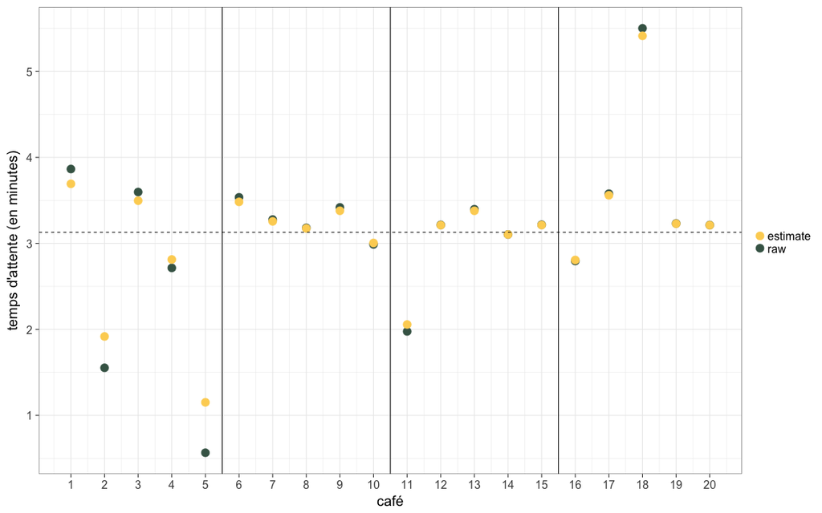

### Aparté: effets fixes et effets aléatoires

Cinq définitions (contradictoires) relevées par [Gelman (2005)](https://projecteuclid.org/euclid.aos/1112967698).

- Fixed effects are constant across individuals, and random effects vary.
- Effects are fixed if they are interesting in themselves or random if there is interest in the underlying population.
- When a sample exhausts the population, the corresponding variable is fixed; when the sample is a small (i.e., negligible) part of the population the corresponding variable is random.
- If an effect is assumed to be a realized value of a random variable, it is called a random effect.
- Fixed effects are estimated using least squares (or, more generally, maximum likelihood) and random effects are estimated with shrinkage.

[Gelman & Hill (2007)](https://www.cambridge.org/core/books/data-analysis-using-regression-and-multilevelhierarchical-models/32A29531C7FD730C3A68951A17C9D983) suggèrent plutôt l'utilisation des termes de *constant effects* et *varying effects*, et de toujours utiliser la modèlisation multi-niveaux, en considérant que ce qu'on appelle *effet fixe* peut simplement être considéré comme un *effet aléatoire* dont la variance serait égale à \( 0 \).

### Régularisation et terminologie

Le fait de faire varier les intercepts de chaque café est simplement une autre manière de régulariser (de manière adaptative), c'est à dire de diminuer le poids accordé aux données dans l'estimation. Le modèle devient à même d'estimer à quel point les groupes (ici les cafés) sont différents, tout en estimant les caractéristiques de chaque café…

Différence entre les **cross-classified** multilevel models et **nested or hierarchical** multilevel models. Le premier type de modèle concerne des données structurées selon deux (ou plus) facteurs aléatoires non *nichés*. Le deuxième type de modèles concerne des données structurées de manière hiérarchique (e.g., un élève dans une classe dans une école dans une ville…). Les deux types de modèles s'écrivent cependant de manière similaire, sur plusieurs *niveaux*.

Le terme “multi-niveaux” (dans notre terminologie) fait donc référence à la structure du modèle, à sa spécification. À distinguer de la structure des données.

### Exemple de modèle "cross-classified"

On pourrait se poser la question de savoir si la récence des cafés (leur âge) ne serait pas une source de variabilité non contrôlée ? Il suffit d'ajouter un intercept aléatoire, et de lui attribuer un prior adaptatif.

\[ \begin{align} w_{i} &\sim \mathrm{Normal}(\mu_{i},\sigma) \\ \mu_{i} &= \alpha + \alpha_{\text{café}[i]} + \alpha_{\text{âge}[i]} \\ \alpha_{\text{café}} &\sim \mathrm{Normal}(5,\sigma_{\text{café}}) \\ \alpha_{\text{âge}} &\sim \mathrm{Normal}(5,\sigma_{\text{âge}}) \\ \alpha &\sim \mathrm{Normal}(0,10) \\ \sigma_{\text{café}} &\sim \mathrm{HalfCauchy}(0,2) \\ \sigma_{\text{âge}} &\sim \mathrm{HalfCauchy}(0,2) \\ \sigma &\sim \mathrm{HalfCauchy}(0,2) \\ \end{align} \]

### Robot et café: varying intercept + varying slope

On s'intéresse maintenant à l'effet du moment de la journée sur le temps d'attente. Attend-on plus le matin, ou l'après-midi ?

\[ \begin{align} w_{i} &\sim \mathrm{Normal}(\mu_{i},\sigma) \\ \mu_{i} &= \alpha_{\text{café}[i]} + \beta_{\text{café}[i]} A_{i} \\ \end{align} \]

Où \( A_{i} \) est une *dummy variable* codée 0/1 pour le matin et l'après-midi et \( \beta_{\text{café}} \) est un paramètre de différence entre le matin et l'après-midi.

Remarque: on sait que les cafés ont des intercepts et des pentes qui covarient… Les cafés populaires seront surchargés le matin et beaucoup moins l'après-midi, résultant en une pente importante. Ces cafés auront aussi un temps d'attente moyen (intercept) plus long. Dans ces cafés, \( \alpha \) est grand et \( \beta \) est loin de zéro. A l'inverse, dans un café peu populaire, le temps d'attente sera faible, ainsi que la différence entre matin et après-midi.

On pourrait donc utiliser la co-variation entre intercept et pente pour faire de meilleures inférences. Faire en sorte que l'estimation de l'intercept informe celle de la pente, et réciproquement.

### Robot et café: varying intercept + varying slope

On s'intéresse maintenant à l'effet du moment de la journée sur le temps d'attente. Attend-on plus le matin, ou l'après-midi ?

\[ \begin{align} w_{i} &\sim \mathrm{Normal}(\mu_{i},\sigma) \\ \mu_{i} &= \alpha_{\text{café}[i]} + \beta_{\text{café}[i]} A_{i} \\ \begin{bmatrix} \alpha_{\text{café}} \\ \beta_{\text{café}} \\ \end{bmatrix} &\sim \mathrm{MVNormal}\bigg(\begin{bmatrix} \alpha \\ \beta \end{bmatrix}, \textbf{S}\bigg) \\ \end{align} \]

La troisième ligne postule que chaque café a un intercept \( \alpha_{\text{café}} \) et une pente \( \beta_{\text{café}} \), définis par un prior gaussien à deux dimensions ayant comme moyennes \( \alpha \) et \( \beta \) et comme matrice de covariance \( \textbf{S} \).

### Aparté: distribution gaussienne multivariée

\[ \mathbf{x} \sim \mathcal{N}(\boldsymbol{\mu}, \boldsymbol{\Sigma}) \]

Où \( \boldsymbol{\mu} \) est un vecteur (à \( k \) dimensions) de moyennes, par exemple: `mu <- c(a,b)`.

\( \boldsymbol{\Sigma} \) est une matrice de covariance de \( k \times k \) dimensions, et qui correspond à la matrice donnée par la fonction `vcov`.

\[ \begin{align} \boldsymbol{\Sigma} &= \begin{pmatrix} \sigma_{\alpha}^{2} & \sigma_{\alpha} \sigma_{\beta} \rho \\ \sigma_{\alpha} \sigma_{\beta} \rho & \sigma_{\beta}^{2} \\ \end{pmatrix} \\ \end{align} \]

### Aparté: distribution gaussienne multivariée

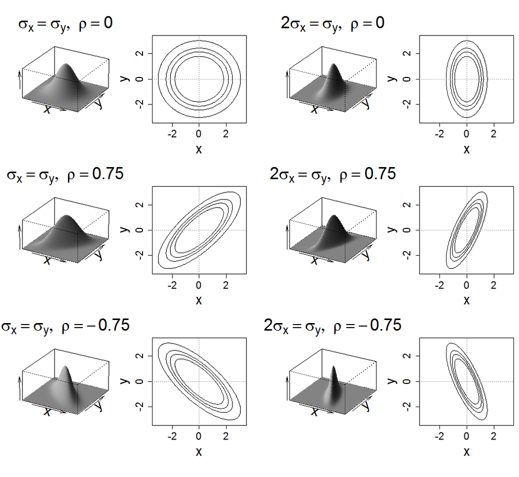

### Aparté: distribution gaussienne multivariée, calcul matriciel

\[ \begin{align} \boldsymbol{\Sigma} &= \begin{pmatrix} \sigma_{\alpha}^{2} & \sigma_{\alpha} \sigma_{\beta} \rho \\ \sigma_{\alpha} \sigma_{\beta} \rho & \sigma_{\beta}^{2} \\ \end{pmatrix} \\ \end{align} \]

Cette matrice peut se construire de deux manières différentes, strictement équivalentes.

```r
sigma_a <- 1
sigma_b <- 0.75
rho <- 0.7
cov_ab <- sigma_a * sigma_b * rho
(Sigma1 <- matrix(c(sigma_a^2, cov_ab, cov_ab, sigma_b^2), ncol = 2) )
```

```
      [,1]   [,2]
[1,] 1.000 0.5250
[2,] 0.525 0.5625
```

### Aparté: distribution gaussienne multivariée, calcul matriciel

\[ \begin{align} \boldsymbol{\Sigma} &= \begin{pmatrix} \sigma_{\alpha}^{2} & \sigma_{\alpha} \sigma_{\beta} \rho \\ \sigma_{\alpha} \sigma_{\beta} \rho & \sigma_{\beta}^{2} \\ \end{pmatrix} \\ \end{align} \]

La deuxième méthode est assez utile puisqu'elle considère séparément les écart-types et les corrélations.

```r
(sigmas <- c(sigma_a, sigma_b) ) # standard deviations
```

```
[1] 1.00 0.75
```

```r
(Rho <- matrix(c(1, rho, rho, 1), nrow = 2) ) # correlation matrix
```

```
     [,1] [,2]
[1,]  1.0  0.7
[2,]  0.7  1.0
```

```r
(Sigma2 <- diag(sigmas) %*% Rho %*% diag(sigmas) )
```

```
      [,1]   [,2]
[1,] 1.000 0.5250
[2,] 0.525 0.5625
```

### Robot et café: varying intercept + varying slope

\[ \begin{align} w_{i} &\sim \mathrm{Normal}(\mu_{i},\sigma) \\ \mu_{i} &= \alpha_{\text{café}[i]} + \beta_{\text{café}[i]} A_{i} \\ \begin{bmatrix} \alpha_{\text{café}} \\ \beta_{\text{café}} \\ \end{bmatrix} &\sim \mathrm{MVNormal}\bigg(\begin{bmatrix} \alpha \\ \beta \end{bmatrix}, \textbf{S}\bigg) \\ \textbf{S} &= \begin{pmatrix} \sigma_{\alpha} & 0 \\ 0 & \sigma_{\beta} \\ \end{pmatrix} \ \textbf{R} \begin{pmatrix} \sigma_{\alpha} & 0 \\ 0 & \sigma_{\beta} \\ \end{pmatrix} \\ \alpha &\sim \mathrm{Normal} (0,10) \\ \beta &\sim \mathrm{Normal} (0,10) \\ \sigma &\sim \mathrm{HalfCauchy} (0,1) \\ \sigma_{\alpha} &\sim \mathrm{HalfCauchy} (0,1) \\ \sigma_{\beta} &\sim \mathrm{HalfCauchy} (0,1) \\ \textbf{R} &\sim \mathrm{LKJcorr}(2) \\ \end{align} \]

\( \textbf{S} \) est définie en factorisant \( \sigma_{\alpha} \), \( \sigma_{\beta} \), et la matrice de corrélation \( \textbf{R} \). La suite du modèle définit simplement les priors pour les effets constants. La dernière ligne spécifie le prior pour \( \textbf{R} \).

### LKJ prior

D'après [Lewandowski, Kurowicka, & Joe (2009)](https://www.sciencedirect.com/science/article/pii/S0047259X09000876). Un seul paramètre \( \zeta \) spécifie la concentration de la distribution du coefficient de corrélation. Le prior \( \mathrm{LKJcorr}(2) \) définit un prior peu informatif pour \( \rho \) qui est sceptique des corrélations extrêmes, proches de \( -1 \) ou de \( 1 \).

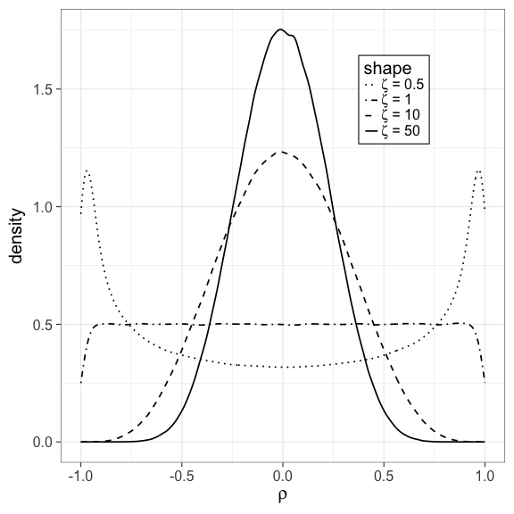

### Modèle map2stan

```r
mod5 <- map2stan(alist(
        wait ~ dnorm(mu, sigma),
        mu <- a_cafe[cafe] + b_cafe[cafe] * afternoon,
        c(a_cafe, b_cafe)[cafe] ~ dmvnorm2(c(a, b), sigma_cafe, Rho),
        a ~ dnorm(0, 10),
        b ~ dnorm(0, 10),
        sigma_cafe ~ dcauchy(0, 2),
        sigma ~ dcauchy(0, 2),
        Rho ~ dlkjcorr(2) ),
        data = d,
        iter = 5000, warmup = 2000,
        chains = 2, cores = parallel::detectCores() )
```

On utilise `c()` pour combiner les paramètres en vecteurs. La distribution `dmvnorm2` est une gaussienne multivariée qui prend en entrée un vecteur de moyennes `c(a, b)`, un vecteur d'écarts-types `c(sigma_cafe)`, et une matrice de corrélation `Rho`.

### Posterior distribution

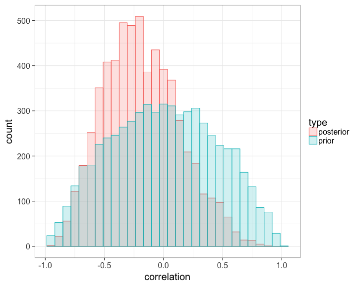

```r
post <- extract.samples(mod5)
R <- rlkjcorr(6000, K = 2, eta = 2)

data.frame(prior = R[, 1, 2], posterior = post$Rho[, 1, 2]) %>%
    gather(type, value, prior:posterior) %>%
    ggplot(aes(x = value, color = type, fill = type) ) +
    geom_histogram(position = "identity", alpha = 0.2) +
    theme_bw(base_size = 20) +
    xlab("correlation")
```

### Shrinkage en deux dimensions

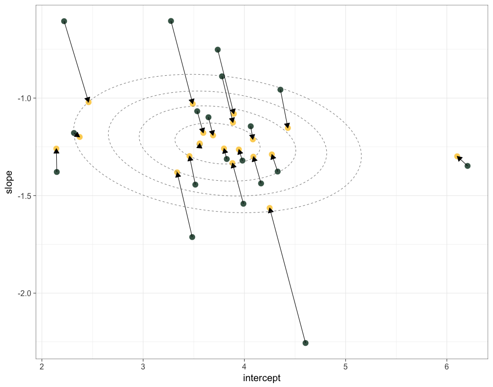

### Paramètres du modèle estimés

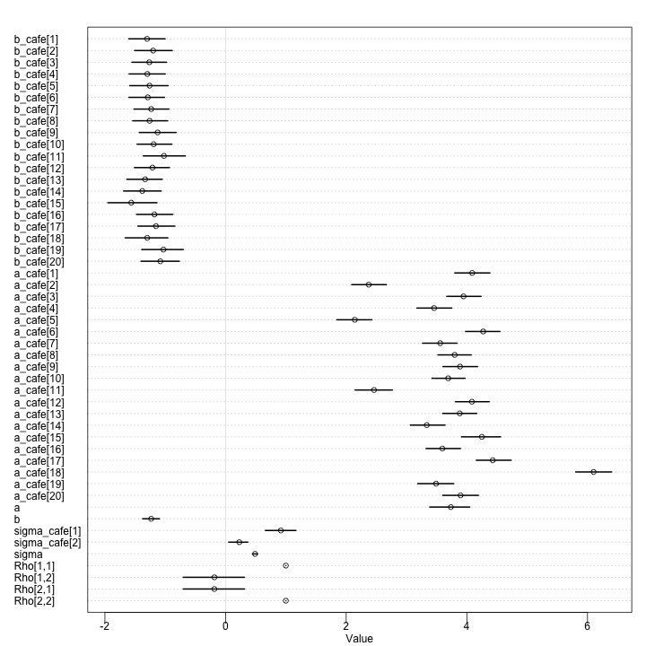

```r
plot(precis(mod5, depth = 2) )
```

### Comparaison de modèles

On compare le premier modèle (*complete pooling model*), le troisième modèle (*partial pooling model*), et le dernier modèle.

```r
compare(mod1, mod2, mod3, mod5)
```

```
      WAIC pWAIC dWAIC weight    SE   dSE
mod5 308.8  26.7   0.0      1 19.96    NA
mod3 507.6  18.1 198.8      0 16.54 16.56
mod2 509.0  19.5 200.2      0 16.72 16.50
mod1 622.4   2.1 313.5      0 21.06 27.36
```

### Comparaison de modèles

```r
precis(mod1, prob = 0.95)
```

```
      Mean StdDev lower 0.95 upper 0.95 n_eff Rhat
a     3.12   0.08       2.96       3.27  4438    1
sigma 1.14   0.06       1.03       1.26  4490    1
```

```r
precis(mod3, prob = 0.95)
```

```
           Mean StdDev lower 0.95 upper 0.95 n_eff Rhat
a          3.12   0.20       2.73       3.52  6000    1
sigma      0.82   0.04       0.74       0.91  6000    1
sigma_cafe 0.86   0.16       0.56       1.17  6000    1
```

```r
precis(mod5, prob = 0.95)
```

```
       Mean StdDev lower 0.95 upper 0.95 n_eff Rhat
a      3.73   0.21       3.31       4.15  4338    1
b     -1.23   0.09      -1.40      -1.06  2549    1
sigma  0.49   0.03       0.44       0.55  2714    1
```

L'estimation du temps d'attente moyen est plus incertaine lorsqu'on prend en compte de nouvelles sources d'erreur. Cependant, l'erreur du modèle (i.e., ce qui n'est pas expliqué), la variation résiduelle \( \sigma \), diminue…

### Travaux pratiques - sleepstudy

```r
library(lme4)

data(sleepstudy)
head(sleepstudy, 20)
```

```
   Reaction Days Subject
1  249.5600    0     308
2  258.7047    1     308
3  250.8006    2     308
4  321.4398    3     308
5  356.8519    4     308
6  414.6901    5     308
7  382.2038    6     308
8  290.1486    7     308
9  430.5853    8     308
10 466.3535    9     308
11 222.7339    0     309
12 205.2658    1     309
13 202.9778    2     309
14 204.7070    3     309
15 207.7161    4     309
16 215.9618    5     309
17 213.6303    6     309
18 217.7272    7     309
19 224.2957    8     309
20 237.3142    9     309
```

### Travaux pratiques - sleepstudy

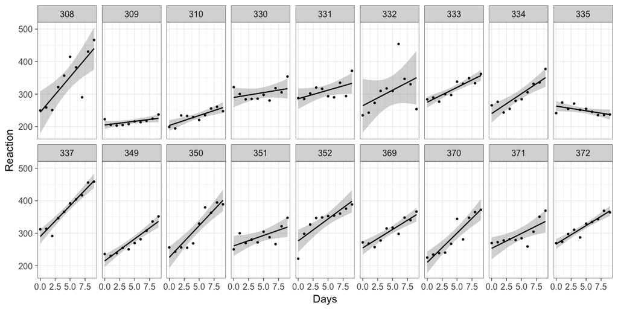

```r
sleepstudy %>%
    ggplot(aes(x = Days, y = Reaction) ) +
    geom_smooth(method = "lm", colour = "black") +
    geom_point() +
    facet_wrap(~Subject, nrow = 2) +
    theme_bw(base_size = 20)
```

### Travaux pratiques - sleepstudy

A vous de construire les modèles mathématiques et les modèles `map2stan` correspondant aux modèles suivants:

- modèle avec seulement l'effet fixe de `Days`
- modèle avec l'effet fixe de `Days` + un effet aléatoire de `Subject` (*random intercept*)
- modèle avec l'effet fixe de `Days` + un effet aléatoire de `Subject` (*random intercept*) + un effet aléatoire de `Days` (*random slope*)

Comparez ensuite ces modèles en utilisant les outils discutés aux cours précédents (e.g., WAIC) et concluez.

### Proposition de solution

```r
fmod0 <- lm(Reaction ~ Days, sleepstudy)
fmod1 <- lmer(Reaction ~ Days + (1|Subject), sleepstudy)
fmod2 <- lmer(Reaction ~ Days + (1 + Days|Subject), sleepstudy)

anova(fmod1, fmod2)
```

```
Data: sleepstudy
Models:
fmod1: Reaction ~ Days + (1 | Subject)
fmod2: Reaction ~ Days + (1 + Days | Subject)
      Df    AIC    BIC  logLik deviance  Chisq Chi Df Pr(>Chisq)
fmod1  4 1802.1 1814.8 -897.04   1794.1
fmod2  6 1763.9 1783.1 -875.97   1751.9 42.139      2  7.072e-10 ***
---
Signif. codes:  0 '***' 0.001 '**' 0.01 '*' 0.05 '.' 0.1 ' ' 1
```

### Proposition de solution

```r
mod6 <- map2stan(alist(
        Reaction ~ dnorm(mu,sigma),
        mu <- a + b_Days * Days,
        a ~ dnorm(200, 100),
        b_Days ~ dnorm(0, 10),
        sigma ~ dcauchy(0, 10) ),
        data = sleepstudy,
        iter = 5000, warmup = 2000,
        chains = 2, cores = parallel::detectCores() )
```

```r
precis(mod6, prob = 0.95)
```

```
         Mean StdDev lower 0.95 upper 0.95 n_eff Rhat
a      251.91   6.57     239.00     265.02  2222    1
b_Days  10.35   1.24       7.95      12.81  2287    1
sigma   47.81   2.58      43.01      52.93  3929    1
```

### Proposition de solution

```r
mod7 <- map2stan(alist(
        Reaction ~ dnorm(mu,sigma),
        mu <- a_Subject[Subject] + b_Days * Days,
        a_Subject[Subject] ~ dnorm(a, sigma_Subject),
        a ~ dnorm(200, 100),
        b_Days ~ dnorm(0, 10),
        sigma ~ dcauchy(0, 10),
        sigma_Subject ~ dcauchy(0, 10) ),
        data = sleepstudy,
        iter = 5000, warmup = 2000,
        chains = 2, cores = parallel::detectCores() )
```

```r
precis(mod7, prob = 0.95)
```

```
                Mean StdDev lower 0.95 upper 0.95 n_eff Rhat
a             251.29   9.83     232.06     270.59  6000    1
b_Days         10.43   0.82       8.88      12.08  2686    1
sigma          31.09   1.76      27.73      34.53  6000    1
sigma_Subject  37.64   7.27      25.15      51.84  6000    1
```

### Proposition de solution

```r
mod8 <- map2stan(alist(
        Reaction ~ dnorm(mu, sigma),
        mu <- a_Subject[Subject] + b_Subject[Subject] * Days,
        c(a_Subject, b_Subject)[Subject] ~ dmvnorm2(c(a, b), sigma_Subject, Rho),
        a ~ dnorm(200, 100),
        b ~ dnorm(0, 10),
        sigma_Subject ~ dcauchy(0, 2),
        sigma ~ dcauchy(0, 2),
        Rho ~ dlkjcorr(2) ),
        data = sleepstudy,
        iter = 5000, warmup = 2000,
        chains = 2, cores = parallel::detectCores() )
```

```r
precis(mod8, prob = 0.95)
```

```
        Mean StdDev lower 0.95 upper 0.95 n_eff Rhat
a     251.31   6.79     237.72     264.60  6000    1
b      10.22   1.57       7.19      13.40  6000    1
sigma  25.86   1.52      22.99      28.83  6000    1
```

### Proposition de solution

```r
compare(mod6, mod7, mod8)
```

```
       WAIC pWAIC dWAIC weight    SE   dSE
mod8 1720.6  32.6   0.0      1 44.24    NA
mod7 1769.8  19.5  49.2      0 28.79 22.78
mod6 1906.7   3.3 186.0      0 21.06 41.62
```